# Introduction to Pandas

- It is a python [3rd party library](https://pandas.pydata.org)
- Used for data analysis and visualization
- Part of Anaconda python distribution
- Best used with Jupyter notebook, can be used with regular python programs
- Main feature is the Data Frame

```python
# Load the pandas library to let python know you will use it
import pandas as pd
```

# What is a Data Frame?

- Its a data structure, like lists and dictionaries
- Consists of rows and columns, similar to SQL tables and excel spreadsheets
  - Columns are attributes or variables
  - Rows are records or single observations
- Operations are typically performed on columns
- Has both numeric and named indexing

# Loading data into a data frame

- Data is usually loaded from an external source, like a csv or excel file.
- Download the weather data set from [vega-dataset](https://raw.githubusercontent.com/vega/vega-datasets/gh-pages/data/weather.csv) (**right click and save as**)
- Place it in the same directory as the jupyter notbook you are working on

```python
# load the data using pandas library
# do you remember what was pd?
pd.read_csv("weather.csv")

# Jupter notebook tip:
# type: pd.
# then hit tab, see what happens
# try also: pd.read_ (then hit tab)
```

|  | location | date | precipitation | temp_max | temp_min | wind | weather |
| --- | --- | --- | --- | --- | --- | --- | --- |
| 0 | Seattle | 2012-01-01 00:00 | 0.0 | 12.8 | 5.0 | 4.7 | drizzle |
| 1 | Seattle | 2012-01-02 00:00 | 10.9 | 10.6 | 2.8 | 4.5 | rain |
| 2 | Seattle | 2012-01-03 00:00 | 0.8 | 11.7 | 7.2 | 2.3 | rain |
| 3 | Seattle | 2012-01-04 00:00 | 20.3 | 12.2 | 5.6 | 4.7 | rain |
| 4 | Seattle | 2012-01-05 00:00 | 1.3 | 8.9 | 2.8 | 6.1 | rain |
| 5 | Seattle | 2012-01-06 00:00 | 2.5 | 4.4 | 2.2 | 2.2 | rain |
| 6 | Seattle | 2012-01-07 00:00 | 0.0 | 7.2 | 2.8 | 2.3 | rain |
| 7 | Seattle | 2012-01-08 00:00 | 0.0 | 10.0 | 2.8 | 2.0 | sun |
| 8 | Seattle | 2012-01-09 00:00 | 4.3 | 9.4 | 5.0 | 3.4 | rain |
| 9 | Seattle | 2012-01-10 00:00 | 1.0 | 6.1 | 0.6 | 3.4 | rain |
| 10 | Seattle | 2012-01-11 00:00 | 0.0 | 6.1 | -1.1 | 5.1 | sun |
| 11 | Seattle | 2012-01-12 00:00 | 0.0 | 6.1 | -1.7 | 1.9 | sun |
| 12 | Seattle | 2012-01-13 00:00 | 0.0 | 5.0 | -2.8 | 1.3 | sun |
| 13 | Seattle | 2012-01-14 00:00 | 4.1 | 4.4 | 0.6 | 5.3 | snow |
| 14 | Seattle | 2012-01-15 00:00 | 5.3 | 1.1 | -3.3 | 3.2 | snow |
| 15 | Seattle | 2012-01-16 00:00 | 2.5 | 1.7 | -2.8 | 5.0 | snow |
| 16 | Seattle | 2012-01-17 00:00 | 8.1 | 3.3 | 0.0 | 5.6 | snow |
| 17 | Seattle | 2012-01-18 00:00 | 19.8 | 0.0 | -2.8 | 5.0 | snow |
| 18 | Seattle | 2012-01-19 00:00 | 15.2 | -1.1 | -2.8 | 1.6 | snow |
| 19 | Seattle | 2012-01-20 00:00 | 13.5 | 7.2 | -1.1 | 2.3 | snow |
| 20 | Seattle | 2012-01-21 00:00 | 3.0 | 8.3 | 3.3 | 8.2 | rain |
| 21 | Seattle | 2012-01-22 00:00 | 6.1 | 6.7 | 2.2 | 4.8 | rain |
| 22 | Seattle | 2012-01-23 00:00 | 0.0 | 8.3 | 1.1 | 3.6 | rain |
| 23 | Seattle | 2012-01-24 00:00 | 8.6 | 10.0 | 2.2 | 5.1 | rain |
| 24 | Seattle | 2012-01-25 00:00 | 8.1 | 8.9 | 4.4 | 5.4 | rain |
| 25 | Seattle | 2012-01-26 00:00 | 4.8 | 8.9 | 1.1 | 4.8 | rain |
| 26 | Seattle | 2012-01-27 00:00 | 0.0 | 6.7 | -2.2 | 1.4 | drizzle |
| 27 | Seattle | 2012-01-28 00:00 | 0.0 | 6.7 | 0.6 | 2.2 | rain |
| 28 | Seattle | 2012-01-29 00:00 | 27.7 | 9.4 | 3.9 | 4.5 | rain |
| 29 | Seattle | 2012-01-30 00:00 | 3.6 | 8.3 | 6.1 | 5.1 | rain |
| ... | ... | ... | ... | ... | ... | ... | ... |
| 2892 | New York | 2015-12-02 00:00 | 3.0 | 13.9 | 8.3 | 2.0 | fog |
| 2893 | New York | 2015-12-03 00:00 | 0.0 | 13.3 | 7.2 | 7.2 | sun |
| 2894 | New York | 2015-12-04 00:00 | 0.0 | 11.7 | 5.0 | 4.7 | sun |
| 2895 | New York | 2015-12-05 00:00 | 0.0 | 11.7 | 1.7 | 2.4 | sun |
| 2896 | New York | 2015-12-06 00:00 | 0.0 | 10.6 | 3.3 | 2.9 | sun |
| 2897 | New York | 2015-12-07 00:00 | 0.0 | 12.8 | 4.4 | 3.4 | drizzle |
| 2898 | New York | 2015-12-08 00:00 | 0.0 | 10.6 | 4.4 | 3.5 | sun |
| 2899 | New York | 2015-12-09 00:00 | 0.0 | 12.8 | 1.1 | 3.4 | sun |
| 2900 | New York | 2015-12-10 00:00 | 0.0 | 15.0 | 8.9 | 3.0 | drizzle |
| 2901 | New York | 2015-12-11 00:00 | 0.0 | 14.4 | 7.8 | 2.7 | drizzle |
| 2902 | New York | 2015-12-12 00:00 | 0.0 | 17.8 | 9.4 | 1.9 | fog |
| 2903 | New York | 2015-12-13 00:00 | 0.0 | 21.1 | 11.7 | 3.1 | drizzle |
| 2904 | New York | 2015-12-14 00:00 | 9.1 | 16.1 | 11.7 | 4.8 | fog |
| 2905 | New York | 2015-12-15 00:00 | 2.3 | 17.8 | 11.7 | 8.2 | fog |
| 2906 | New York | 2015-12-16 00:00 | 1.3 | 11.7 | 7.2 | 4.1 | fog |
| 2907 | New York | 2015-12-17 00:00 | 29.7 | 15.0 | 10.0 | 4.1 | fog |
| 2908 | New York | 2015-12-18 00:00 | 0.3 | 14.4 | 3.9 | 6.1 | sun |
| 2909 | New York | 2015-12-19 00:00 | 0.0 | 5.0 | 2.2 | 9.0 | sun |
| 2910 | New York | 2015-12-20 00:00 | 0.0 | 6.7 | 1.7 | 5.1 | sun |
| 2911 | New York | 2015-12-21 00:00 | 0.0 | 12.8 | 3.3 | 5.3 | sun |
| 2912 | New York | 2015-12-22 00:00 | 4.8 | 15.6 | 11.1 | 3.8 | fog |
| 2913 | New York | 2015-12-23 00:00 | 29.5 | 17.2 | 8.9 | 4.5 | fog |
| 2914 | New York | 2015-12-24 00:00 | 0.5 | 20.6 | 13.9 | 4.9 | fog |
| 2915 | New York | 2015-12-25 00:00 | 2.5 | 17.8 | 11.1 | 0.9 | fog |
| 2916 | New York | 2015-12-26 00:00 | 0.3 | 15.6 | 9.4 | 4.8 | drizzle |
| 2917 | New York | 2015-12-27 00:00 | 2.0 | 17.2 | 8.9 | 5.5 | fog |
| 2918 | New York | 2015-12-28 00:00 | 1.3 | 8.9 | 1.7 | 6.3 | snow |
| 2919 | New York | 2015-12-29 00:00 | 16.8 | 9.4 | 1.1 | 5.3 | fog |
| 2920 | New York | 2015-12-30 00:00 | 9.4 | 10.6 | 5.0 | 3.0 | fog |
| 2921 | New York | 2015-12-31 00:00 | 1.5 | 11.1 | 6.1 | 5.5 | fog |

2922 rows × 7 columns

# Now it is your turn

Download [airport.csv](https://raw.githubusercontent.com/vega/vega-datasets/gh-pages/data/airports.csv) then load it into the notebook

**Remember:** Right click on the link and select **save target as**

# How to work with the data?

- You must place it in a variable so you can refer to it
- The current data was displayed and not assigned to a variable, so you cannot use it
- Assign it to a variable named **my_df**

```python
my_df = pd.read_csv("weather.csv")
```

```python
# Your turn: Load airports.csv into airports_df
```

# Let us discover how the data looks like

```python
my_df.head()
```

|  | location | date | precipitation | temp_max | temp_min | wind | weather |
| --- | --- | --- | --- | --- | --- | --- | --- |
| 0 | Seattle | 2012-01-01 00:00 | 0.0 | 12.8 | 5.0 | 4.7 | drizzle |
| 1 | Seattle | 2012-01-02 00:00 | 10.9 | 10.6 | 2.8 | 4.5 | rain |
| 2 | Seattle | 2012-01-03 00:00 | 0.8 | 11.7 | 7.2 | 2.3 | rain |
| 3 | Seattle | 2012-01-04 00:00 | 20.3 | 12.2 | 5.6 | 4.7 | rain |
| 4 | Seattle | 2012-01-05 00:00 | 1.3 | 8.9 | 2.8 | 6.1 | rain |

```python
# You can pass a number in the head() method to show more data
# show 10 items (try it)

# do the same for airports_df
```

```python
# To know which columns are available use the columns attribute
my_df.columns
```

```
Index(['location', 'date', 'precipitation', 'temp_max', 'temp_min', 'wind',
       'weather'],
      dtype='object')
```

```python
# Your turn: explore the columns for airports_df
```

# Data types

- Each **column** will have its own data type
- Remember, variables will be in columns
- Observations in rows
- Use dtypes attribute of to discover columns and datatypes
  - **OOP**: What is the difference between a *function*, a *method*, an *attribute*, and a *variable*?

```python
my_df.dtypes
```

```
location          object
date              object
precipitation    float64
temp_max         float64
temp_min         float64
wind             float64
weather           object
dtype: object
```

```python
# Your turn: Find out the data types for the airports_df column
```

```python
# Pandas uses data types provided by numpy
# load numpy
import numpy as np

# convert the column to datetime
my_df.date.astype(np.datetime64)
```

```
0      2012-01-01
1      2012-01-02
2      2012-01-03
3      2012-01-04
4      2012-01-05
5      2012-01-06
6      2012-01-07
7      2012-01-08
8      2012-01-09
9      2012-01-10
10     2012-01-11
11     2012-01-12
12     2012-01-13
13     2012-01-14
14     2012-01-15
```

[output cut: 47 more lines]

```python
# an alternative way to do it is using
pd.to_datetime(my_df.date).head() # do you remember head method?
```

```
0   2012-01-01
1   2012-01-02
2   2012-01-03
3   2012-01-04
4   2012-01-05
Name: date, dtype: datetime64[ns]
```

```python
# now let us examine the date column
my_df.date.head()

# why is it still of type object?
# How to fix it?
```

```
0    2012-01-01 00:00
1    2012-01-02 00:00
2    2012-01-03 00:00
3    2012-01-04 00:00
4    2012-01-05 00:00
Name: date, dtype: object
```

```python
# just like the dataframe, the command creates a copy
# but does not store it
# We need to replace the old date column with the new one
my_df.date = my_df.date.astype(np.datetime64)
```

```python
# check the types
my_df.dtypes
```

```
location                 object
date             datetime64[ns]
precipitation           float64
temp_max                float64
temp_min                float64
wind                    float64
weather                  object
dtype: object
```

```python
# Your turn: examine the airports_df dataframe
# are there any date columns that you can convert?
# Check then umeric columns, what should their data type be?
```

# Why convert an object column into a date column?

- As you will find out later, pandas can do more fancy things if it knows the column is a date
- For example:
  - Sort
  - Filter based on date range
  - Date arethmatic
- Always make sure date/time columns have the correct data type

# Indexing Columns

- Using square brackets [ ]
- Using dot notation .

```python
# a single column is known as a series
my_df['location']
```

```
0        Seattle
1        Seattle
2        Seattle
3        Seattle
4        Seattle
5        Seattle
6        Seattle
7        Seattle
8        Seattle
9        Seattle
10       Seattle
11       Seattle
12       Seattle
13       Seattle
14       Seattle
```

[output cut: 47 more lines]

```python
# Some methods that work on Dataframes also work on Series
my_df['location'].head()
```

```
0    Seattle
1    Seattle
2    Seattle
3    Seattle
4    Seattle
Name: location, dtype: object
```

```python
# Dot notation to access series
my_df.location.head()
```

```
0    Seattle
1    Seattle
2    Seattle
3    Seattle
4    Seattle
Name: location, dtype: object
```

```python
# Your turn: Try to index the columns for airports_df using square brackets and dot notation
# Use head() to get an idea of what the data is
```

```python
# Descriptive statistics
my_df['location'].describe()
```

```
count         2922
unique           2
top       New York
freq          1461
Name: location, dtype: object
```

```python
# works also on dataframe
my_df.describe()
```

|  | precipitation | temp_max | temp_min | wind |
| --- | --- | --- | --- | --- |
| count | 2922.000000 | 2922.000000 | 2922.000000 | 2922.000000 |
| mean | 2.944764 | 16.769131 | 8.612320 | 4.101129 |
| std | 7.695286 | 8.644596 | 7.511776 | 1.880791 |
| min | 0.000000 | -7.700000 | -16.000000 | 0.400000 |
| 25% | 0.000000 | 10.000000 | 3.300000 | 2.700000 |
| 50% | 0.000000 | 16.100000 | 8.900000 | 3.800000 |
| 75% | 1.800000 | 23.900000 | 13.900000 | 5.100000 |
| max | 118.900000 | 37.800000 | 26.700000 | 16.200000 |

```python
# Different data types will have different descriptives
my_df['date'].describe()
```

```
count                    2922
unique                   1461
top       2013-06-05 00:00:00
freq                        2
first     2012-01-01 00:00:00
last      2015-12-31 00:00:00
Name: date, dtype: object
```

```python
my_df.precipitation.describe()
```

```
count    2922.000000
mean        2.944764
std         7.695286
min         0.000000
25%         0.000000
50%         0.000000
75%         1.800000
max       118.900000
Name: precipitation, dtype: float64
```

```python
# Your turn: Use describe() on airports_df

# Which columns are included in describe?

# Try it on the columns that were excluded:

# Why were these columns excluded?
```

# You can also plot a dataframe

Pandas will try to show it in the best way possible

```python
my_df.plot()
```

```python
# You need to tell pandas that you want to display plots in the notebook
%matplotlib inline
```

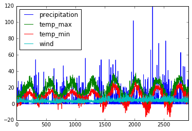

```python
# now try it
my_df.plot()
```

# Don't forget!

Always include in your notebook:

```
# this is the first cell in your notebook
import pandas as pd
%matplotlib inline   # dont forget this
```

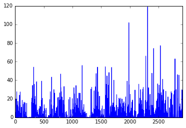

```python
# It's more meaningful to plot Series
my_df['precipitation'].plot()
```

```python
# Remember plots show change from one observation to the next
my_df['wind'].plot()

# in some cases it might not be useful
```

[output not shown]

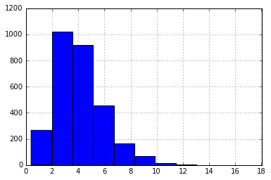

```python
# you can try a histogram
my_df['wind'].hist()

# Which is useful to know distributions
```

# How can you find out if percipitation is usually high in the year or low?

```python
# Your turn:
```

```python
# Sometime pandas cannot plot it
my_df['location'].plot()
```

[output not shown]

```python
# Your turn: try to plot the columns in airport_df using either plot() or hist()


# What can you find out about the data?
```

```python
# Such variables are usually categorical and you can get frequencies like so
my_df['location'].value_counts()
```

```
New York    1461
Seattle     1461
Name: location, dtype: int64
```

```python
# Your turn: Examine the columns for airports_df
# what would be the best columns to check frequencies for?
# try it:


# The best columns are:

# The reason frequencies is best calculated on them is because:

# What did you find out about your data?
```

# Are data frames immutable?